# Description

## Clustering, entity extraction and similarities of resumes texts

Majority of world’s unstructured data is in the textual form. Looking at the volume, variety and velocity of such textual data, it is imperative to employ Text Mining techniques to extract the relevant information, transforming unstructured data into structured form, so that further insights, processing, analysis, visualizations are possible.

We decided to show you our approach to extracting relevant entities by which we group resume of our company and also find similar resumes to particular one.

### Extract texts from files

Firstly, we had to read all the possible formats of resumes files. We've used [textract](https://textract.readthedocs.io/en/stable/), which allows to extract text from different sources: pdf, doc, docx, img, rtf, ect. Set of resumes texts was saved to csv file

### Import necessary libs and read the file

```python
import pandas as pd
import numpy as np
import matplotlib.pyplot as plt
import seaborn as sns

import re
from gensim import corpora
from nltk.corpus import stopwords
from nltk.tokenize import RegexpTokenizer
from pymystem3 import Mystem
from sklearn.feature_extraction.text import TfidfVectorizer

import umap
import scipy.cluster.hierarchy as shc


from annoy import AnnoyIndex
```

```python
df = pd.read_csv('raw_texst_eng.csv')
```

### Preprosessing and tokenization

Tokenization is the first step in text analytics. Word tokenizer breaks text paragraph into words.

Before that we make some preprosessing: remove numbers and strange chars, make lemmatezation and remove stopwords. We leave signs like '#', '+' because they occur in technologies names.

#### Stopwords

Stopset consists of: standart english stopwords, words with one letter and custom stopwords. The last one has words which have been defined as noise during subsequent clustering

```python
def remove_numbers(documents):
    return [''.join([i for i in doc if not i.isdigit()])
                      for doc in documents]

def remove_strange_char(documents):
    return [re.sub(r'[^a-zA-Z0-9\#_+-]',r' ', doc)
                  for doc in documents]

def make_tokenize(documents):
    return [doc.lower().split()
                      for doc in documents]

def remove_stopwords(documents):
    stopset = get_stopset(documents)
    return [[word for word in doc if word not in stopset]
                      for doc in documents]

def lemmetization(documents):
    lemm = Mystem()
    return [[''.join(lemm.lemmatize(word)).replace('\n', '') for word in doc]
                      for doc in documents]

def get_stopset(documents) -> set:
    my_stopwords = pd.read_csv('my_stop_list.csv',header=None).values[:,0].tolist()

    unigrams = [word for doc in documents for word in doc if len(word) == 1]

    standart_stopwords = stopwords.words('english')

    return set(unigrams + standart_stopwords + my_stopwords)
```

```python
docs = df.clean_text.fillna('').tolist()
docs = remove_strange_char(docs)
docs = remove_numbers(docs)

docs = make_tokenize(docs)
docs = lemmetization(docs)

docs = remove_stopwords(docs)
```

### Vectorization

One of the most commonly used vectorizer is [TF-iDF](https://en.wikipedia.org/wiki/Tf%E2%80%93idf) (term frequency–inverse document frequency). It transforms each unique word to value, which can be interpreted as "importance" of word in a particular text.

#### N-grams

N-gram is a sequence of n items from a given sample of text. It allows to take into account collocations. N-grams can be used similar to single words and be added to general features space.

Success of text analysis highly depends on purity of features. The key point of that research is selection of max_df and min_df. Tuning of the parameters can get really important n-grams.

```python
corpus = [' '.join(doc) for doc in docs]

def dummy_fun(doc):
    return doc

vectorizer = TfidfVectorizer(ngram_range=(1,3),
                            max_df=0.5,
                            min_df=0.05,
                            tokenizer=dummy_fun,
                            token_pattern=None,
                            preprocessor=dummy_fun)

X = vectorizer.fit_transform(docs)
```

### Projection

To visualize the texts we use powerful and fast [UMAP](https://arxiv.org/abs/1802.03426). It allows us to get projections to 2D and 3D. We use the first one. Using UMAP projections we tuning vectorizer parameters based on iterative method.

```python
def get_umap(data, c=None, n_neighbors=50, min_dist=0.2, n_components=2, metric='cosine', title=''):
    fit = umap.UMAP(
        n_neighbors=n_neighbors,
        min_dist=min_dist,
        n_components=n_components,
        metric=metric
    )
    u = fit.fit_transform(data)
    return u

data = X.toarray()
umap = get_umap(data)

df['umap_0'] = umap[:,0]
df['umap_1'] = umap[:,1]
```

After all iterations we have obtained the next picture. As we can see, there are few separate clusters.

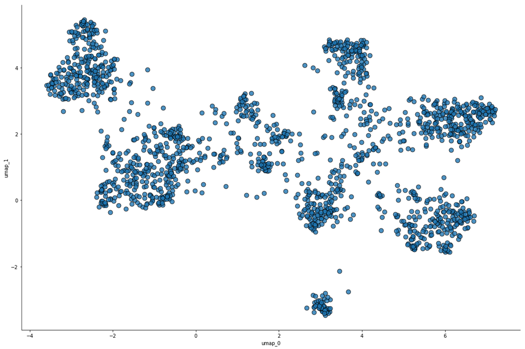

```python
plt.figure(figsize=(10,7))
sns.lmplot(x="umap_0",
           y="umap_1",
           data=df,
           fit_reg=False,
           legend=True,
           height=10,
           aspect=1.5,
           palette="gist_ncar",
           scatter_kws={'edgecolor':'k',
                       's':80})
```

### Clustering

Hierarchical clustering allows to visualize connections between points and it's good approach to choose number of clusters. As we can see, our data can be split to 4 big clusters.

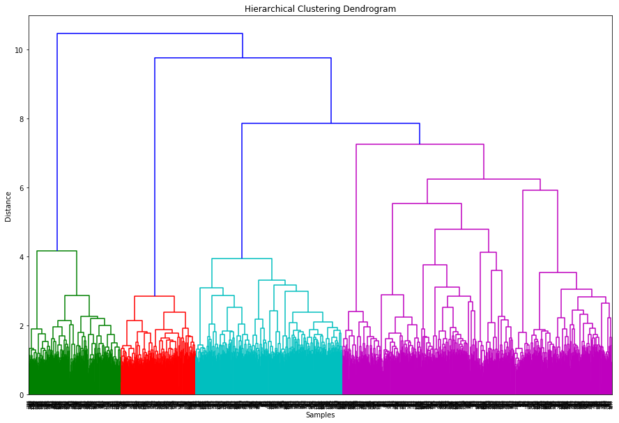

```python
Z = shc.linkage(data, method='ward')

plt.figure(figsize=(15, 10))
plt.title('Hierarchical Clustering Dendrogram')
plt.xlabel('Samples')
plt.ylabel('Distance')
dend = shc.dendrogram(Z)
```

### Define number of clusters

However, we awaited to get more cluster due to texts origin. Therefore, we started to tune a distance threshold. Finally, there are 13 groups of resumes

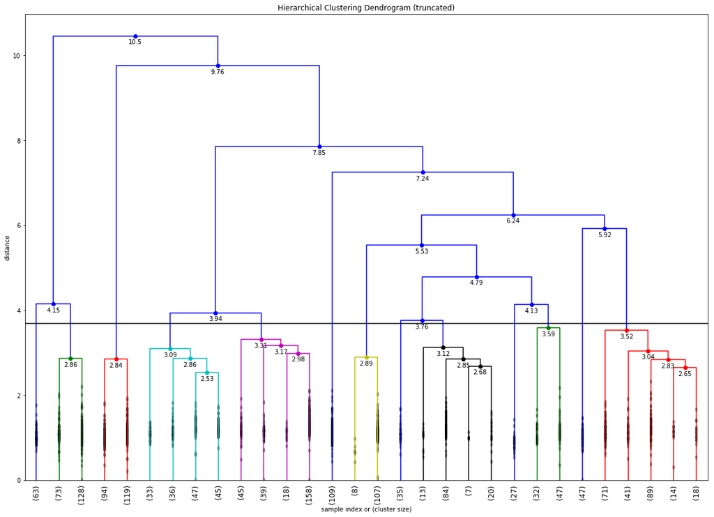

```python
def fancy_dendrogram(*args, **kwargs):
    max_d = kwargs.pop('max_d', None)
    if max_d and 'color_threshold' not in kwargs:
        kwargs['color_threshold'] = max_d
    annotate_above = kwargs.pop('annotate_above', 0)

    ddata = shc.dendrogram(*args, **kwargs)

    if not kwargs.get('no_plot', False):
        plt.title('Hierarchical Clustering Dendrogram (truncated)')
        plt.xlabel('sample index or (cluster size)')
        plt.ylabel('distance')
        for i, d, c in zip(ddata['icoord'], ddata['dcoord'], ddata['color_list']):
            x = 0.5 * sum(i[1:3])
            y = d[1]
            if y > annotate_above:
                plt.plot(x, y, 'o', c=c)
                plt.annotate("%.3g" % y, (x, y), xytext=(0, -5),
                             textcoords='offset points',
                             va='top', ha='center')
        if max_d:
            plt.axhline(y=max_d, c='k')
    return ddata

plt.figure(figsize=(20, 14))
max_d=3.68
fancy_dendrogram(
    Z,
    truncate_mode='lastp',
#     p=13,
    leaf_rotation=90.,
    leaf_font_size=12.,
    show_contracted=True,
    max_d=max_d
#     annotate_above=10,  # useful in small plots so annotations don't overlap
)

plt.show()
```

### Cluters projection

Look at the projection. Сolours are added corresponing new clusters. Only points from 9-th cluster are scattered.

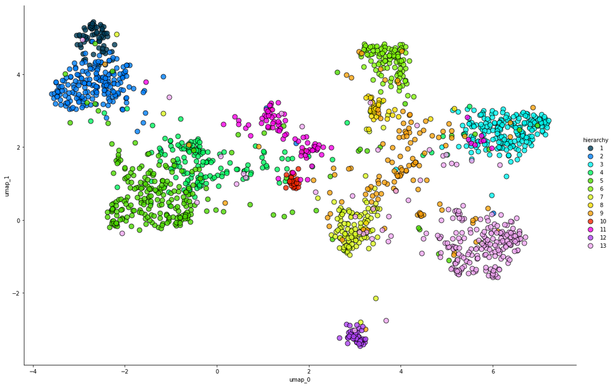

```python
from scipy.cluster.hierarchy import fcluster

k = 13
temp = fcluster(Z, k, criterion='maxclust')

df['hierarchy'] = temp

df_tf = pd.DataFrame(data, columns=vectorizer.get_feature_names())
df_tf['hierarchy'] = temp

plt.figure(figsize=(10,7))
sns.lmplot(x="umap_0",
           y="umap_1",
           data=df,
           fit_reg=False,
           hue='hierarchy',
           legend=True,
           height=10,
           aspect=1.5,
           palette="gist_ncar",
           scatter_kws={'edgecolor':'k',
                       's':80})
```

### How to interpret the clusters?

We use the following approach:

```
1. Group all features by the clusters.
2. Calculate mean of grouped data.
3. Sort values by the clusters in turn.
```

The last one gives us words or n-grams, which have the biggest "importance" values. Then we try to describe and name clusters based on words in the top of the table.

Finally, there are clusters names. We can add labels to the previous illustrations.

```python
cl_names = ['QA Automation', 'QA Manual', '.Net Developers', 'BA + Data Science', 'sales + hr', 'iOS Developers', 'Java Developers', 'Android Developers', 'Other', 'DB Developers', 'Database Admin', 'Salesforce Developers', 'php + frontend']
```

```python
p = len(cl_names)
cm = sns.light_palette("green", as_cmap=True)

info_group = df_tf.groupby('hierarchy').mean().T.sort_values(3, ascending=False)
info_group.columns = cl_names
info_group = (info_group * 100).round(1).head(50)
info_group = info_group.style.background_gradient(cmap=cm)
info_group
```

|  | QA Automation | QA Manual | .Net Developers | BA + Data Science | sales + hr | iOS Developers | Java Developers | Android Developers | Other | DB Developers | Database Admin | Salesforce Developers | php + frontend |
| --- | --- | --- | --- | --- | --- | --- | --- | --- | --- | --- | --- | --- | --- |
| net | 0.9 | 1.2 | 33 | 1.3 | 1.2 | 1.5 | 0.8 | 2.4 | 3.5 | 0.9 | 4.5 | 2.7 | 2 |
| asp | 0.2 | 0.2 | 18.3 | 0.2 | 0.2 | 0.3 | 0.1 | 1.1 | 0.9 | 0.4 | 2.1 | 1.3 | 0.5 |
| asp net | 0.2 | 0.1 | 17 | 0.2 | 0.2 | 0.3 | 0.1 | 1 | 0.7 | 0.4 | 1.7 | 1.3 | 0.5 |
| c# | 2.5 | 0.8 | 12.3 | 0.9 | 0.5 | 2.3 | 0.8 | 3 | 2.8 | 1 | 3.7 | 1.3 | 1.8 |
| mvc | 0.1 | 0.1 | 8.7 | 0.2 | 0.2 | 1.4 | 3.5 | 1 | 1.2 | 0 | 0.7 | 1.1 | 1.1 |
| sql | 4.3 | 3.9 | 8.5 | 3.3 | 0.6 | 1.2 | 4.3 | 2.7 | 3.1 | 14.6 | 12.7 | 1.8 | 2.4 |
| net mvc | 0.2 | 0 | 8.5 | 0.1 | 0.1 | 0 | 0 | 0.2 | 0.4 | 0 | 0.8 | 0.5 | 0.1 |
| asp net mvc | 0.2 | 0 | 8.3 | 0.1 | 0.1 | 0 | 0 | 0.2 | 0.4 | 0 | 0.8 | 0.5 | 0.1 |
| framework | 5.8 | 0.5 | 7 | 0.7 | 0.6 | 1.8 | 2.5 | 1.2 | 2.5 | 0.6 | 0.8 | 2 | 2.8 |
| server | 3.2 | 2.6 | 7 | 2 | 0.5 | 1.9 | 3.1 | 2.7 | 3.6 | 4.1 | 14.6 | 1.5 | 1.9 |
| net developer | 0 | 0 | 6.7 | 0.2 | 0 | 0.1 | 0.1 | 0 | 0.2 | 0 | 0.2 | 0.1 | 0.1 |
| ms | 2.2 | 3.6 | 6.5 | 4 | 2.2 | 0.9 | 2 | 1.5 | 2.2 | 3.1 | 9.1 | 0.8 | 1.2 |
| sql server | 2.4 | 1.5 | 6.1 | 1.4 | 0.2 | 0.3 | 1.2 | 0.7 | 1.1 | 1.3 | 9.1 | 0.5 | 0.5 |
| entity | 0.3 | 0.1 | 6 | 0.1 | 0.2 | 0 | 0 | 0.4 | 0.4 | 0 | 0.4 | 0.5 | 0 |
| entity framework | 0.3 | 0 | 5.8 | 0.1 | 0.1 | 0 | 0 | 0.4 | 0.3 | 0 | 0.4 | 0.5 | 0 |
| ms sql | 1.6 | 1.2 | 5.6 | 1.3 | 0.2 | 0.3 | 1.4 | 0.5 | 0.9 | 1.3 | 6.8 | 0.2 | 0.6 |
| javascript | 1.4 | 0.4 | 5.5 | 0.5 | 0.3 | 0.9 | 4.6 | 1.5 | 4 | 0.4 | 1.3 | 6.7 | 9.4 |
| wcf | 0.1 | 0 | 5 | 0.1 | 0 | 0.2 | 0 | 0 | 0.5 | 0 | 1 | 0.4 | 0.1 |
| html | 1.8 | 2.2 | 5 | 0.7 | 0.7 | 0.9 | 3.7 | 3 | 2.9 | 0.8 | 1.7 | 5.7 | 10.4 |
| studio | 2.1 | 1.3 | 4.9 | 1 | 0.4 | 1.8 | 0.8 | 3.6 | 2.5 | 0.8 | 2.6 | 0.4 | 1.6 |
| api | 2.9 | 0.9 | 4.8 | 0.2 | 0.2 | 3.9 | 2 | 7.1 | 2.6 | 0.5 | 0.4 | 3.3 | 3 |
| jquery | 0.2 | 0.1 | 4.7 | 0.2 | 0.1 | 0.3 | 3.2 | 0.8 | 2 | 0 | 0.4 | 3.6 | 8.7 |
| ado | 0.2 | 0.1 | 4.5 | 0.1 | 0 | 0.1 | 0 | 0.5 | 0.8 | 0.5 | 0.9 | 0 | 0 |
| visual | 1.5 | 1 | 4.5 | 0.8 | 0.3 | 1.4 | 0.6 | 1.3 | 3 | 0.9 | 2 | 1.2 | 1 |
| ado net | 0.2 | 0.1 | 4.5 | 0.1 | 0 | 0.1 | 0 | 0.5 | 0.6 | 0.2 | 0.7 | 0 | 0 |
| microsoft | 1.8 | 3.9 | 4.5 | 1.6 | 1.5 | 0.6 | 0.7 | 1 | 1.7 | 1.1 | 5.8 | 1.1 | 1 |
| application | 3.2 | 4 | 4.4 | 1.3 | 0.7 | 10.5 | 5.9 | 8.2 | 5.1 | 3.7 | 2.7 | 2.8 | 2 |
| visual studio | 1.6 | 0.7 | 4.3 | 0.4 | 0.1 | 1.2 | 0.4 | 1.2 | 2 | 0.5 | 1.4 | 0.3 | 0.8 |
| css | 1.8 | 1.5 | 4.3 | 0.5 | 0.7 | 0.6 | 3.7 | 3 | 2.6 | 0.3 | 0.7 | 6.2 | 10.7 |
| windows | 2.4 | 3.9 | 4.3 | 1 | 1.3 | 2 | 1.7 | 2.9 | 3.7 | 3.3 | 8.2 | 0.6 | 2.2 |
| services | 1.4 | 1.3 | 4.2 | 2.5 | 2.1 | 1.7 | 2.6 | 1.7 | 1.8 | 0.8 | 3.6 | 3.7 | 1.2 |
| wpf | 0.1 | 0.1 | 4.2 | 0.1 | 0.2 | 0.2 | 0 | 0 | 0.4 | 0 | 0.1 | 0.1 | 0 |
| linq | 0 | 0 | 3.9 | 0.1 | 0.1 | 0.2 | 0 | 0.2 | 0.5 | 0 | 0.2 | 0.5 | 0.1 |
| c# net | 0.4 | 0.1 | 3.8 | 0.1 | 0.3 | 0.4 | 0.1 | 0.4 | 0.6 | 0 | 0.7 | 0.3 | 0.1 |
| net c# | 0.1 | 0.1 | 3.8 | 0.1 | 0.1 | 0.1 | 0 | 0.2 | 0.3 | 0.1 | 0.9 | 0.2 | 0.2 |
| using | 3.9 | 1.9 | 3.7 | 2.1 | 1 | 2.5 | 2.5 | 2.6 | 2.4 | 1.9 | 2.4 | 3.7 | 3.1 |
| ms sql server | 1.5 | 0.9 | 3.7 | 0.8 | 0.1 | 0.2 | 0.6 | 0.5 | 0.6 | 0.6 | 5 | 0.1 | 0.3 |
| net framework | 0.1 | 0.1 | 3.6 | 0.1 | 0.1 | 0.1 | 0.3 | 0.1 | 0.6 | 0 | 0.1 | 0.1 | 0 |
| design | 2.6 | 3.7 | 3.6 | 3.6 | 1 | 3.7 | 3.1 | 3.1 | 6.3 | 4.2 | 2.6 | 2 | 2.8 |
| net web | 0.1 | 0 | 3.4 | 0 | 0 | 0 | 0 | 0 | 0.1 | 0 | 0 | 0 | 0 |
| software engineer | 0.2 | 0.1 | 3.4 | 0.3 | 0.2 | 3.9 | 4.8 | 4.9 | 9 | 0.9 | 1.6 | 0.3 | 1.4 |
| c# asp | 0 | 0 | 3.4 | 0 | 0 | 0.1 | 0.1 | 0.4 | 0.2 | 0.2 | 0.3 | 0.3 | 0.2 |
| mssql | 0.5 | 0.1 | 3.4 | 0.3 | 0.2 | 0.1 | 0.5 | 0.2 | 0.3 | 0 | 0.7 | 0.3 | 0.7 |
| forms | 0.2 | 0.3 | 3.3 | 0.6 | 0.4 | 0.5 | 0.2 | 0 | 1 | 0.2 | 0.4 | 0.1 | 0.2 |
| c# asp net | 0 | 0 | 3.3 | 0 | 0 | 0.1 | 0.1 | 0.4 | 0.2 | 0.2 | 0.3 | 0.3 | 0.2 |
| html css | 1.3 | 1.3 | 3.3 | 0.4 | 0.4 | 0.5 | 3 | 2.4 | 1.8 | 0.3 | 0.5 | 4.3 | 8.3 |
| net asp | 0 | 0 | 3.3 | 0 | 0 | 0 | 0 | 0.1 | 0 | 0 | 0.2 | 0.2 | 0 |
| software developer | 0.1 | 0.2 | 3.1 | 0.5 | 0.2 | 2.6 | 2.5 | 1.2 | 8 | 0.4 | 1.5 | 2.2 | 1 |
| data | 1.5 | 2.3 | 3.1 | 8.7 | 1.9 | 4.5 | 3.9 | 2.7 | 2.8 | 13.2 | 5.9 | 5.4 | 1.9 |
| ajax | 0.5 | 0.1 | 3 | 0.2 | 0.1 | 0.1 | 2 | 1.6 | 1.7 | 0.2 | 0.1 | 1 | 4.7 |

```
values passed to leaf_label_func
leaves :  [3265, 3311, 3308, 3315, 3318, 3299, 3312, 3263, 3316, 3154, 3320, 3246, 3319]
```

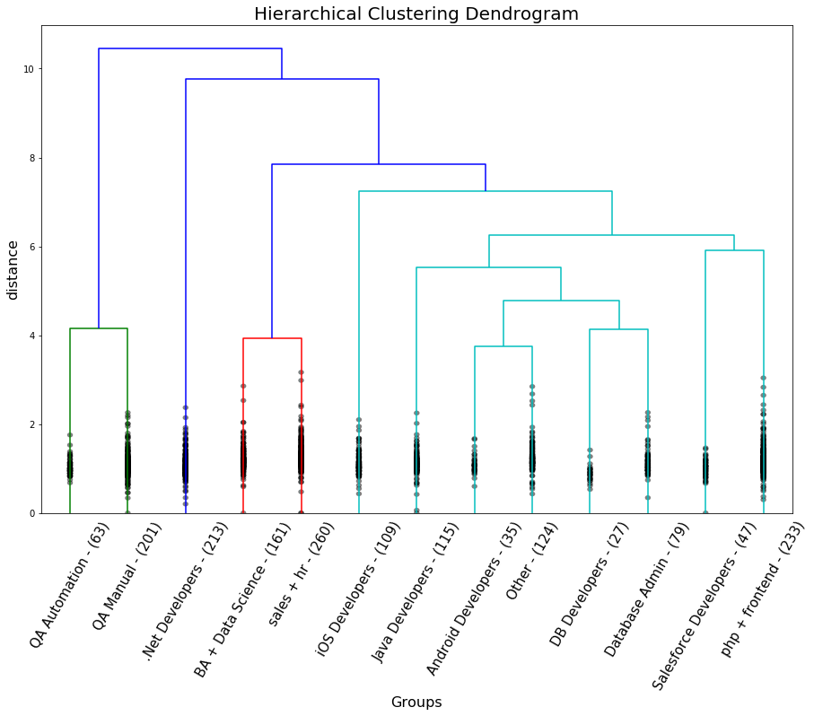

```python
labels = cl_names
p = len(labels)

plt.figure(figsize=(15,10))
plt.title('Hierarchical Clustering Dendrogram', fontsize=20)
plt.xlabel('Groups', fontsize=16)
plt.ylabel('distance', fontsize=16)

R = shc.dendrogram(
                Z,
                truncate_mode='lastp',  # show only the last p merged clusters
                p=p,  # show only the last p merged clusters
                no_plot=True,
                )

print("values passed to leaf_label_func\nleaves : ", R["leaves"])


temp = {R["leaves"][ii]:(labels[ii], R["ivl"][ii]) for ii in range(len(R["leaves"]))}
def llf(xx):
    return "{} - {}".format(*temp[xx])


shc.dendrogram(
            Z,
            truncate_mode='lastp',  # show only the last p merged clusters
            p=p,  # show only the last p merged clusters
            leaf_label_func=llf,
            leaf_rotation=60,
            leaf_font_size=15.,
            show_contracted=True,  # to get a distribution impression in truncated branches
            )
plt.show()
```

```python
df['hierarchy_name'] = df['hierarchy'].apply(lambda x: cl_names[x - 1])
```

[figure not shown]

```python
plt.figure(figsize=(10,7))
sns.lmplot( x="umap_0",
           y="umap_1",
           data=df,
           fit_reg=False,
           hue='hierarchy_name',
           legend=True,
           height=10,
           aspect=1.5,
           palette="gist_ncar",
           scatter_kws={'edgecolor':'k',
                       's':80})
```

### Similarities

After we have got the clusters and their names let's try to find similar resumes based on tf-idf features.

[Annoy](https://github.com/spotify/annoy) (Approximate Nearest Neighbors Oh Yeah) is a C++ library with Python bindings to search for points in space that are close to a given query point. It allows us to get top n resumes are similar to particular one. To comparison given resumes it's possible to visualize their features. Below an example are shown.

```python
def perc_func(x, cv_id, h):
    if x.name != cv_id:
        return (x - h[cv_id]).fillna(0)
    else:
        return x

def get_matching(cv_id, n_similar, single_tree, relative=False):
    neighbours = single_tree.get_nns_by_vector(data[cv_id], n=n_similar)

    table = df_tf.loc[neighbours].drop(['group', 'hierarchy'],1).T.sort_values(cv_id, ascending=False)
    indexes = set()

    for cv in neighbours:
        indexes.update(set(table.sort_values(cv, ascending=False).index[:7].tolist()))


    h = table.loc[indexes].sort_values(cv_id, ascending=False)

    info = h.apply(lambda x: perc_func(x, cv_id, h)) if relative else h

    info = (info * 100).round(1).style.bar(align='mid', color=['#d65f5f', '#5fba7d'])

    return neighbours, info


def show_matching(cv_id, n_similar=8, metric='euclidean'):

    num_features = data.shape[1]
    single_tree = AnnoyIndex(num_features, metric=metric)

    i = 0
    for vector in data:
        single_tree.add_item(i, vector)

        i += 1

    single_tree.build(1)

    neighbours, info = get_matching(cv_id, n_similar, single_tree,relative=False)
    return neighbours, info
```

```python
res_id = 544
n_similar = 6


show_matching(res_id, n_similar=n_similar, metric='euclidean')[1]
```

|  | 544 | 1515 | 529 | 1219 | 104 | 1242 |
| --- | --- | --- | --- | --- | --- | --- |
| net | 38 | 55.2 | 41.4 | 46.4 | 39.5 | 48.9 |
| employees | 28.9 | 0 | 0 | 23.5 | 0 | 0 |
| net developer | 24.4 | 27 | 0 | 17.7 | 25.4 | 19.7 |
| microsoft | 24.4 | 24.2 | 10.6 | 5.3 | 5.1 | 3 |
| ms | 17.3 | 0 | 11.3 | 0 | 11.2 | 15.7 |
| se | 16.9 | 0 | 0 | 0 | 0 | 0 |
| bug fixing | 16.4 | 0 | 17.9 | 0 | 0 | 0 |
| asp net | 12.2 | 20.3 | 16 | 26.6 | 25.5 | 18.5 |
| asp | 12.1 | 20.1 | 15.8 | 26.3 | 25.2 | 18.3 |
| sql | 11.4 | 15.7 | 16.5 | 4.1 | 11.8 | 20.6 |
| ms sql | 11.2 | 0 | 12.2 | 0 | 8.8 | 20.4 |
| server | 8.5 | 10.6 | 11.1 | 4.6 | 22.1 | 12.9 |
| linq | 8.2 | 13.7 | 21.6 | 0 | 0 | 15 |
| ado net | 7.6 | 12.6 | 19.9 | 0 | 0 | 27.7 |
| ado | 7.5 | 12.4 | 19.6 | 0 | 0 | 27.2 |
| certified | 7.1 | 23.7 | 15.6 | 7.7 | 0 | 0 |
| asp net mvc | 7.1 | 0 | 6.2 | 7.7 | 18.5 | 0 |
| applications | 4.7 | 11.7 | 8.2 | 0 | 19.5 | 5.7 |
| pc | 0 | 0 | 0 | 17.7 | 0 | 0 |
| name | 0 | 0 | 17.4 | 0 | 0 | 0 |
| planning | 0 | 0 | 0 | 18 | 0 | 0 |
| proficiency | 0 | 20.1 | 0 | 0 | 0 | 4.9 |
| win | 0 | 0 | 3.7 | 0 | 0 | 30.9 |

## Conclusions

We've considered how can be organized unstructured text data for specific field, namely, recruting. With the right feature engineering it's possible to split resumes into different groups without using complex algorithms.

Interesting, that TF-iDF transformation is a good way not to only high model performance but also to understanding unlabeled data.